# KSooklall_Final_Project

Kenan Sooklall

5/8/2021

### Exercise 1

Using R, generate a random variable X that has 10,000 random uniform numbers from 1 to N, where N can be any number of your choosing greater than or equal to 6. Then generate a random variable Y that has 10,000 random normal numbers with a mean of $\mu=\sigma=(N+1)/2$

```r
set.seed(42)
n <- 10000
N <- 20
mu <- (N+1)/2

df <- data.frame(X=runif(n, min=1, max=N), Y=rnorm(n, mean=mu, sd =mu))
df %>% summary()
```

```
##        X                Y
##  Min.   : 1.005   Min.   :-31.954
##  1st Qu.: 5.658   1st Qu.:  3.312
##  Median :10.497   Median : 10.431
##  Mean   :10.480   Mean   : 10.411
##  3rd Qu.:15.263   3rd Qu.: 17.526
##  Max.   :19.997   Max.   : 55.945
```

```r
x = as.numeric(sub('.*:', '', summary(df)[3,1]))
print(x)
```

```
## [1] 10.497
```

```r
y = as.numeric(sub('.*:', '', summary(df)[2,2]))
print(y)
```

```
## [1] 3.312
```

Probability. Calculate as a minimum the below probabilities a through c. Assume the small letter “x” is estimated as the median of the X variable, and the small letter “y” is estimated as the 1st quartile of the Y variable. Interpret the meaning of all probabilities.

$ P(X>x | X>y) = P(X>y & X>x) / P(X>y) $

```r
(df %>% filter(X>x & X>y) %>% nrow() / n) / (df %>% filter(X>y) %>% nrow()/n)
```

```
## [1] 0.5716246
```

$P(X>x, Y>y)$

```r
df %>% filter(X>x & Y>y) %>% nrow() / n
```

```
## [1] 0.3732
```

$ P(X<x | X>y) = P(X<x & X>y) / P(X > y) $

```r
(df %>% filter(X<x & X>y) %>% nrow() / n) / (df %>% filter(X>y) %>% nrow()/n)
```

```
## [1] 0.4283754
```

Investigate whether P(X>x and Y>y)=P(X>x)P(Y>y) by building a table and evaluating the marginal and joint probabilities.

```r
ptable <- df %>%
  mutate(A=(X<x)&(Y<y), B=(X>x)&(Y<y), C=(X<x)&(Y>y), D=(X>x)&(Y>y)) %>%
  select(A,B,C,D) %>%
  colSums() %>%
  matrix(nrow=2)

colnames(ptable) <- c('Y < y','Y > y')
rownames(ptable) <- c('X < x','X > x')
totalSums = sum(ptable)
```

Marginal Probability: P(X>x) * P(Y>y)

```r
Y_gt_y <- colSums(ptable)[2] / totalSums
X_gt_x <- rowSums(ptable)[2] / totalSums

X_gt_x * Y_gt_y
```

```
## X > x
## 0.375
```

Joint Probability: P(X>x & Y>y)

```r
ptable[2,2] / totalSums
```

```
## [1] 0.3732
```

Check to see if independence holds by using Fisher’s Exact Test and the Chi Square Test. What is the difference between the two? Which is most appropriate?

```r
chisq.test(ptable)
```

```
##
##  Pearson's Chi-squared test with Yates' continuity correction
##
## data:  ptable
## X-squared = 0.65333, df = 1, p-value = 0.4189
```

```r
fisher.test(ptable)
```

```
##
##  Fisher's Exact Test for Count Data
##
## data:  ptable
## p-value = 0.4189
## alternative hypothesis: true odds ratio is not equal to 1
## 95 percent confidence interval:
##  0.8780932 1.0546192
## sample estimates:
## odds ratio
##  0.9623146
```

For both Fisher’s Exact Test and the Chi Square Test the p-value = 0.4189 which is greater than 0.05 therefore we cannot reject the null hypothesis. Chi Square Test is for large (n>30) samples while Fisher’s Exact Test is for smaller sized samples. Given than n=10000 the Chi Square Test is appropriate.

### Exercise 2

The data set was taken from kaggle

```r
path <- '/home/kenan/Documents/learning/masters/CUNY-SPS-Masters-DS/DATA_605/final_exam/'
df <- read.csv(paste0(path, 'train.csv'))
sdf <- read.csv(paste0(path, 'sample_submission.csv'))
tdf <- read.csv(paste0(path, 'test.csv'))
```

Data Descriptions

- SalePrice - Sale price in dollars. This is the target variable that you’re trying to predict.
- MSSubClass: The building class
- MSZoning: The general zoning classification
- LotFrontage: Linear feet of street connected to property
- LotArea: Lot size in square feet
- Street: Type of road access
- Alley: Type of alley access
- LotShape: General shape of property
- LandContour: Flatness of the property
- Utilities: Type of utilities available
- LotConfig: Lot configuration
- LandSlope: Slope of property
- Neighborhood: Physical locations within Ames city limits
- Condition1: Proximity to main road or railroad
- Condition2: Proximity to main road or railroad (if a second is present)
- BldgType: Type of dwelling
- HouseStyle: Style of dwelling
- OverallQual: Overall material and finish quality
- OverallCond: Overall condition rating
- YearBuilt: Original construction date
- YearRemodAdd: Remodel date
- RoofStyle: Type of roof
- RoofMatl: Roof material
- Exterior1st: Exterior covering on house
- Exterior2nd: Exterior covering on house (if more than one material)
- MasVnrType: Masonry veneer type
- MasVnrArea: Masonry veneer area in square feet
- ExterQual: Exterior material quality
- ExterCond: Present condition of the material on the exterior
- Foundation: Type of foundation
- BsmtQual: Height of the basement
- BsmtCond: General condition of the basement
- BsmtExposure: Walkout or garden level basement walls
- BsmtFinType1: Quality of basement finished area
- BsmtFinSF1: Type 1 finished square feet
- BsmtFinType2: Quality of second finished area (if present)
- BsmtFinSF2: Type 2 finished square feet
- BsmtUnfSF: Unfinished square feet of basement area
- TotalBsmtSF: Total square feet of basement area
- Heating: Type of heating
- HeatingQC: Heating quality and condition
- CentralAir: Central air conditioning
- Electrical: Electrical system
- 1stFlrSF: First Floor square feet
- 2ndFlrSF: Second floor square feet
- LowQualFinSF: Low quality finished square feet (all floors)
- GrLivArea: Above grade (ground) living area square feet
- BsmtFullBath: Basement full bathrooms
- BsmtHalfBath: Basement half bathrooms
- FullBath: Full bathrooms above grade
- HalfBath: Half baths above grade
- Bedroom: Number of bedrooms above basement level
- Kitchen: Number of kitchens
- KitchenQual: Kitchen quality
- TotRmsAbvGrd: Total rooms above grade (does not include bathrooms)
- Functional: Home functionality rating
- Fireplaces: Number of fireplaces
- FireplaceQu: Fireplace quality
- GarageType: Garage location
- GarageYrBlt: Year garage was built
- GarageFinish: Interior finish of the garage
- GarageCars: Size of garage in car capacity
- GarageArea: Size of garage in square feet
- GarageQual: Garage quality
- GarageCond: Garage condition
- PavedDrive: Paved driveway
- WoodDeckSF: Wood deck area in square feet
- OpenPorchSF: Open porch area in square feet
- EnclosedPorch: Enclosed porch area in square feet
- 3SsnPorch: Three season porch area in square feet
- ScreenPorch: Screen porch area in square feet
- PoolArea: Pool area in square feet
- PoolQC: Pool quality
- Fence: Fence quality
- MiscFeature: Miscellaneous feature not covered in other categories
- MiscVal: $Value of miscellaneous feature
- MoSold: Month Sold
- YrSold: Year Sold
- SaleType: Type of sale
- SaleCondition: Condition of sale

#### Descriptive and Inferential Statistics.

Provide univariate descriptive statistics and appropriate plots for the training data set. Provide a scatterplot matrix for at least two of the independent variables and the dependent variable.

As the above ground living area increases more space for a full batch.

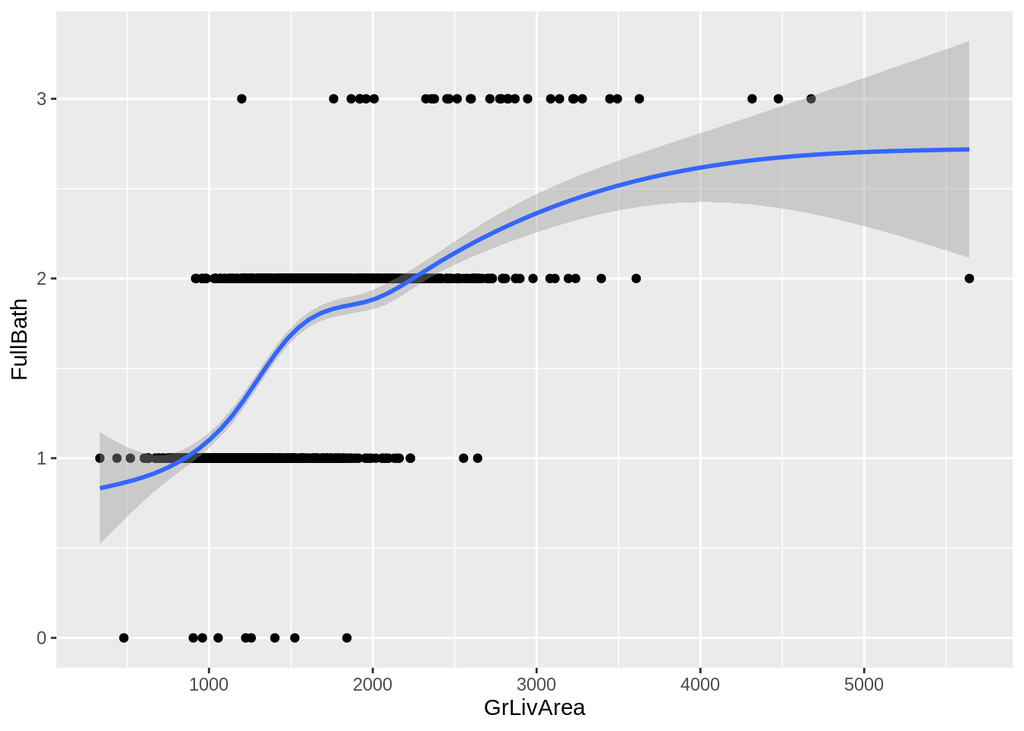

```r
df %>% ggplot(aes(x=GrLivArea, y=FullBath)) +
  geom_point() +
  geom_smooth()
```

I would think the linear feet of street connected to property would correlate to the lot area; however, it looks like they do.

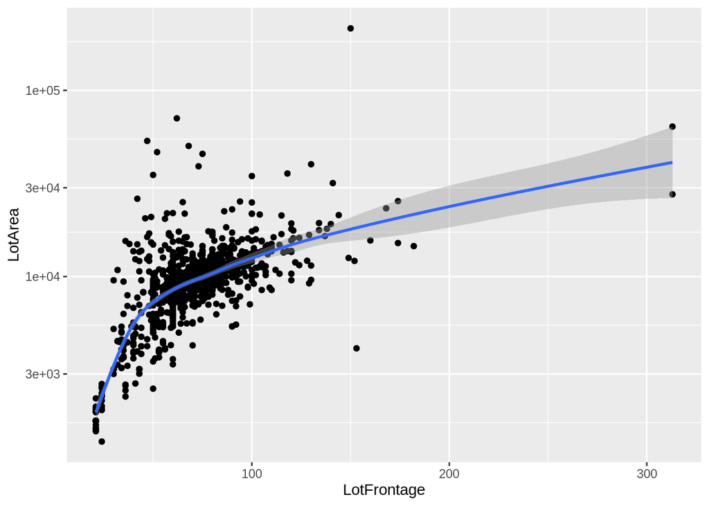

```r
df %>% ggplot(aes(x=LotFrontage, y=LotArea)) +
  geom_point() +
  geom_smooth() +
  scale_y_log10()
```

Higher scale price correspond to houses that have more rooms above grade

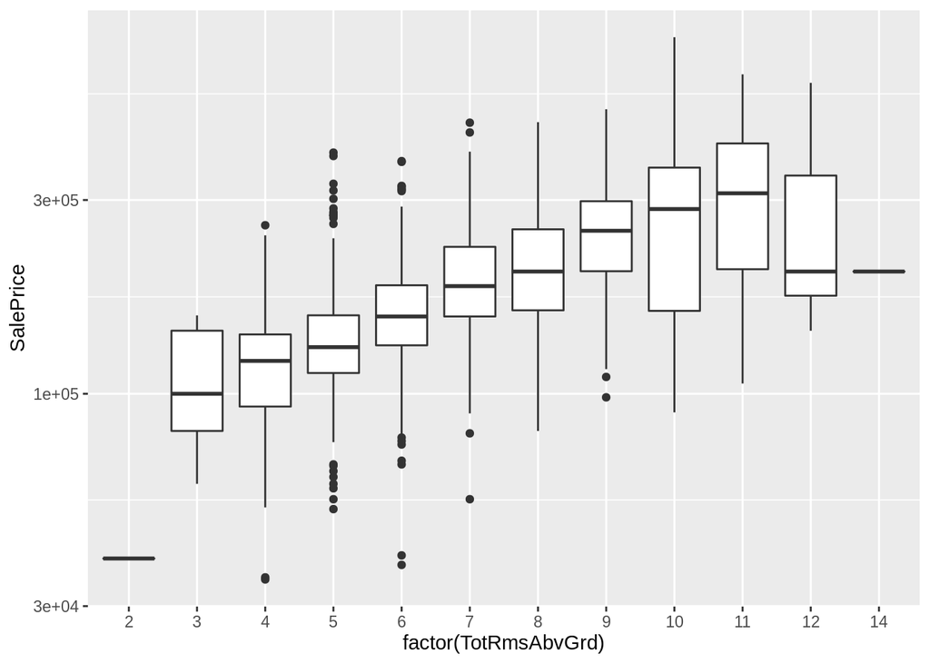

```r
df %>% ggplot(aes(x=factor(TotRmsAbvGrd), y=SalePrice)) +
  geom_boxplot() +
  scale_y_log10()
```

Distribution of the SalePrice. Most of the house prices are within 200k

```r
df %>% select(SalePrice) %>% summary()
```

```
##    SalePrice
##  Min.   : 34900
##  1st Qu.:129975
##  Median :163000
##  Mean   :180921
##  3rd Qu.:214000
##  Max.   :755000
```

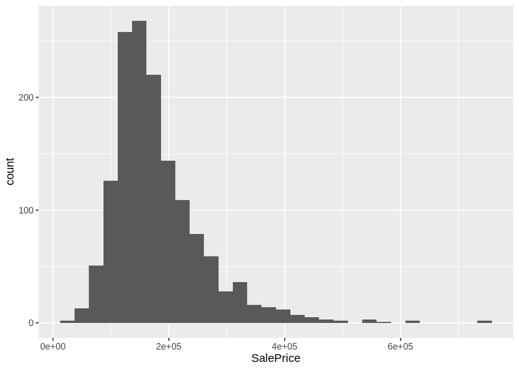

```r
df %>% ggplot(aes(x=SalePrice)) +
  geom_histogram()
```

Even among the expensive house (3rd Qu), there are a lot of outliars

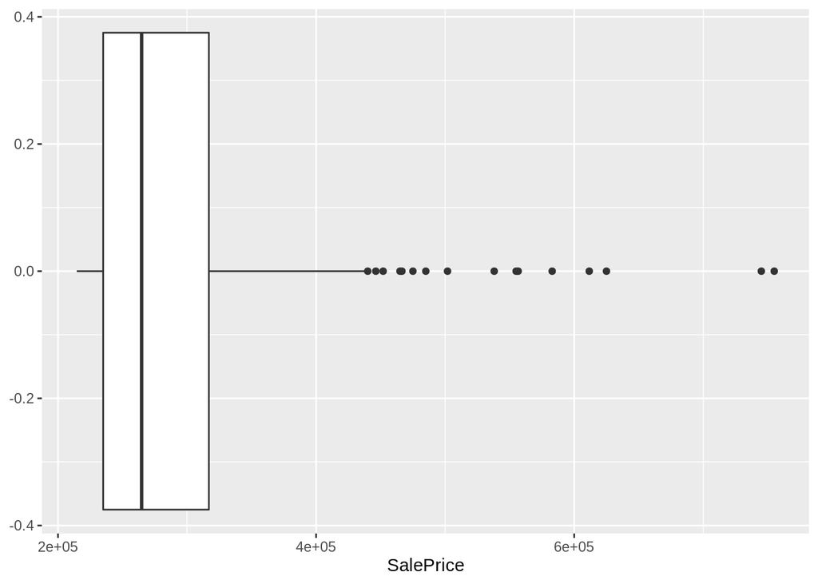

```r
df %>% filter(SalePrice > 214000) %>% ggplot(aes(x=SalePrice)) +
  geom_boxplot()
```

2010 wasn’t good for the housing market, a lot less sales

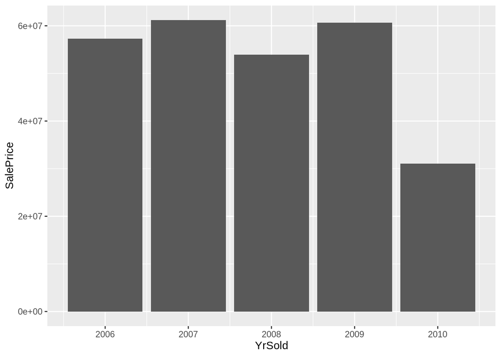

```r
df %>% ggplot(aes(x=YrSold, y=SalePrice)) +
  geom_col()
```

Fill in some missing values LotFrontage - Fill by median

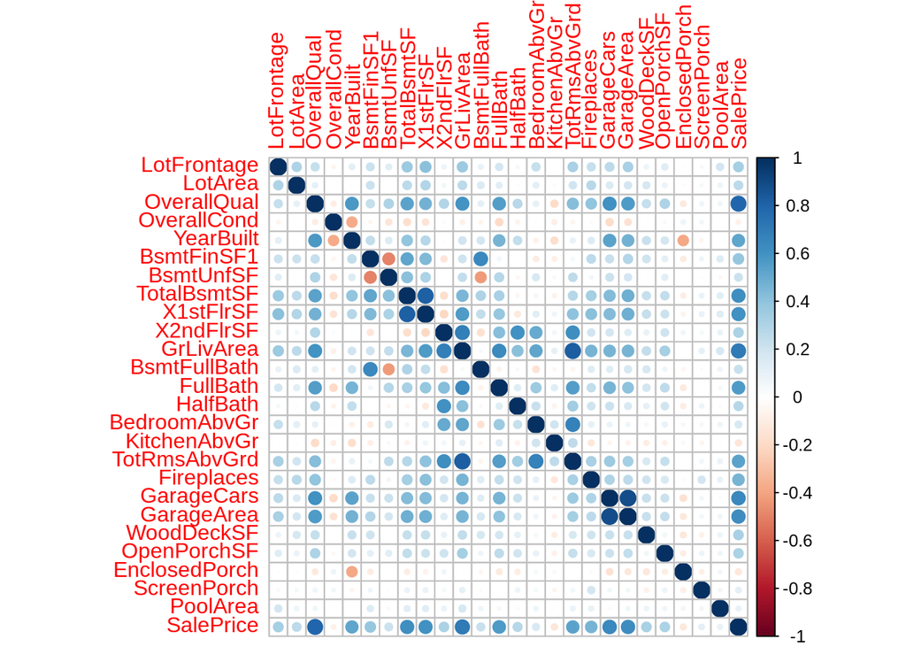

```r
corr_df <- df %>%
  mutate(LotFrontage=ifelse(is.na(LotFrontage), median(LotFrontage, na.rm=T), LotFrontage)) %>%
  select(where(is.numeric)) %>%
  select(-c('Id', 'YearRemodAdd', 'GarageYrBlt', 'MasVnrArea', 'MSSubClass', 'BsmtFinSF2', 'X3SsnPorch', 'YrSold', 'MoSold', 'MiscVal', 'BsmtHalfBath', 'LowQualFinSF'))

corr_df %>%
  cor() %>%
  corrplot()
```

```r
lmodel <- lm(SalePrice ~., data=corr_df)
summary(lmodel)
```

```
##
## Call:
## lm(formula = SalePrice ~ ., data = corr_df)
##
## Residuals:
##     Min      1Q  Median      3Q     Max
## -498716  -16932   -1928   13553  295194
##
## Coefficients:
##                 Estimate Std. Error t value Pr(>|t|)
## (Intercept)   -8.335e+05  1.112e+05  -7.497 1.14e-13 ***
## LotFrontage    4.486e+01  4.999e+01   0.897 0.369663
## LotArea        4.312e-01  1.041e-01   4.144 3.61e-05 ***
## OverallQual    1.743e+04  1.192e+03  14.617  < 2e-16 ***
## OverallCond    5.542e+03  9.512e+02   5.826 6.99e-09 ***
## YearBuilt      3.837e+02  5.668e+01   6.769 1.88e-11 ***
## BsmtFinSF1     1.477e+01  6.157e+00   2.399 0.016575 *
## BsmtUnfSF      4.823e+00  6.248e+00   0.772 0.440284
## TotalBsmtSF    7.720e+00  7.148e+00   1.080 0.280345
## X1stFlrSF      3.466e+01  2.046e+01   1.694 0.090469 .
## X2ndFlrSF      2.688e+01  2.022e+01   1.329 0.183897
## GrLivArea      1.773e+01  2.004e+01   0.885 0.376485
## BsmtFullBath   7.441e+03  2.516e+03   2.958 0.003149 **
## FullBath       3.285e+03  2.849e+03   1.153 0.249121
## HalfBath      -1.147e+03  2.718e+03  -0.422 0.672996
## BedroomAbvGr  -9.809e+03  1.693e+03  -5.793 8.48e-09 ***
## KitchenAbvGr  -2.496e+04  4.951e+03  -5.042 5.20e-07 ***
## TotRmsAbvGrd   6.046e+03  1.252e+03   4.829 1.52e-06 ***
## Fireplaces     2.973e+03  1.790e+03   1.660 0.097068 .
## GarageCars     1.083e+04  2.910e+03   3.721 0.000206 ***
## GarageArea     4.075e+00  9.907e+00   0.411 0.680910
## WoodDeckSF     2.609e+01  8.135e+00   3.207 0.001369 **
## OpenPorchSF   -1.635e+00  1.539e+01  -0.106 0.915451
## EnclosedPorch  1.173e+01  1.720e+01   0.682 0.495510
## ScreenPorch    5.521e+01  1.753e+01   3.149 0.001673 **
## PoolArea      -4.731e+01  2.416e+01  -1.958 0.050377 .
## ---
## Signif. codes:  0 '***' 0.001 '**' 0.01 '*' 0.05 '.' 0.1 ' ' 1
##
## Residual standard error: 35550 on 1434 degrees of freedom
## Multiple R-squared:  0.8032, Adjusted R-squared:  0.7998
## F-statistic: 234.1 on 25 and 1434 DF,  p-value: < 2.2e-16
```

Derive a correlation matrix for any three quantitative variables in the dataset.

```r
quantitative_variables <- c('OverallQual', 'GrLivArea', 'TotalBsmtSF')
corr_matrix <- df %>%
  select(all_of(quantitative_variables)) %>%
  cor()
```

Test the hypotheses that the correlations between each pairwise set of variables is 0 and provide an 80% confidence interval. Discuss the meaning of your analysis. Would you be worried about familywise error? Why or why not?

```r
cor.test(df$OverallQual, df$SalePrice, method = 'pearson', conf.level = 0.80)
```

```
##
##  Pearson's product-moment correlation
##
## data:  df$OverallQual and df$SalePrice
## t = 49.364, df = 1458, p-value < 2.2e-16
## alternative hypothesis: true correlation is not equal to 0
## 80 percent confidence interval:
##  0.7780752 0.8032204
## sample estimates:
##       cor
## 0.7909816
```

```r
cor.test(df$GrLivArea, df$SalePrice, method = 'pearson', conf.level = 0.80)
```

```
##
##  Pearson's product-moment correlation
##
## data:  df$GrLivArea and df$SalePrice
## t = 38.348, df = 1458, p-value < 2.2e-16
## alternative hypothesis: true correlation is not equal to 0
## 80 percent confidence interval:
##  0.6915087 0.7249450
## sample estimates:
##       cor
## 0.7086245
```

```r
cor.test(df$TotalBsmtSF, df$SalePrice, method = 'pearson', conf.level = 0.80)
```

```
##
##  Pearson's product-moment correlation
##
## data:  df$TotalBsmtSF and df$SalePrice
## t = 29.671, df = 1458, p-value < 2.2e-16
## alternative hypothesis: true correlation is not equal to 0
## 80 percent confidence interval:
##  0.5922142 0.6340846
## sample estimates:
##       cor
## 0.6135806
```

All p-values are less than the significance 0.05 thus conclude that the pairwise variables are correlated. There is concern that we might commit a type 1 error, rejecting the null hypothesis when H_o is actually true.

#### Linear Algebra and Correlation.

Invert your correlation matrix from above. (This is known as the precision matrix and contains variance inflation factors on the diagonal.) Multiply the correlation matrix by the precision matrix, and then multiply the precision matrix by the correlation matrix. Conduct LU decomposition on the matrix.

```r
precision_matrix = inv(corr_matrix)

cp_matrix = corr_matrix %*% precision_matrix
pc_matrix = precision_matrix %*% corr_matrix

lu_corr = expand(lu(corr_matrix))

print(lu_corr$L)
```

```
## 3 x 3 Matrix of class "dtrMatrix" (unitriangular)
##      [,1]      [,2]      [,3]
## [1,] 1.0000000         .         .
## [2,] 0.5930074 1.0000000         .
## [3,] 0.5378085 0.2096790 1.0000000
```

```r
print(lu_corr$U)
```

```
## 3 x 3 Matrix of class "dtrMatrix"
##      [,1]      [,2]      [,3]
## [1,] 1.0000000 0.5930074 0.5378085
## [2,]         . 0.6483422 0.1359438
## [3,]         .         . 0.6822575
```

#### Calculus-Based Probability & Statistics.

Many times, it makes sense to fit a closed form distribution to data. Select a variable in the Kaggle.com training dataset that is skewed to the right, shift it so that the minimum value is absolutely above zero if necessary. Then load the MASS package and run fitdistr to fit an exponential probability density function. (See https://stat.ethz.ch/R-manual/R-devel/library/MASS/html/fitdistr.html ).

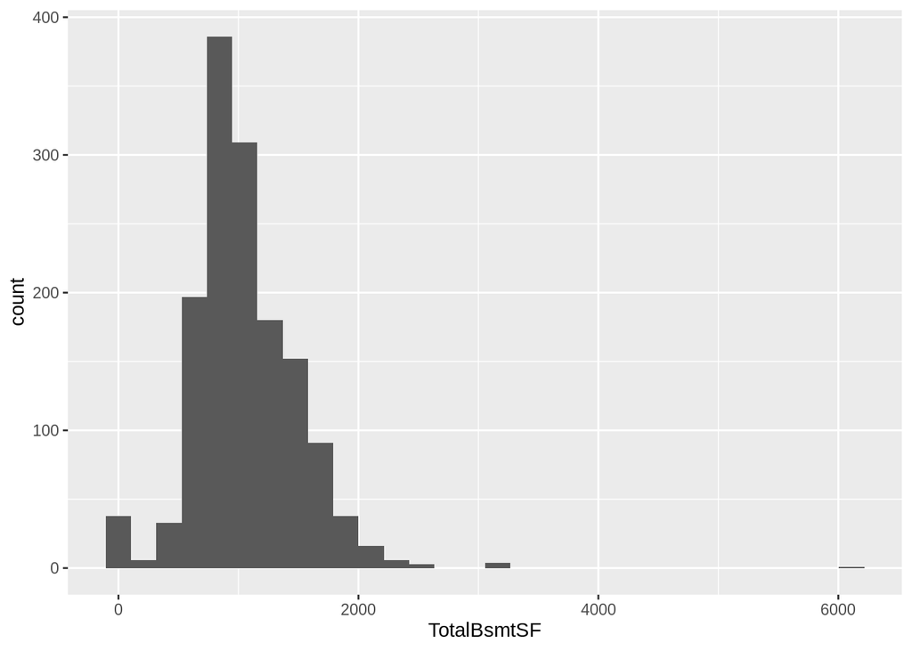

```r
df %>% ggplot(aes(x=TotalBsmtSF)) + geom_histogram()
```

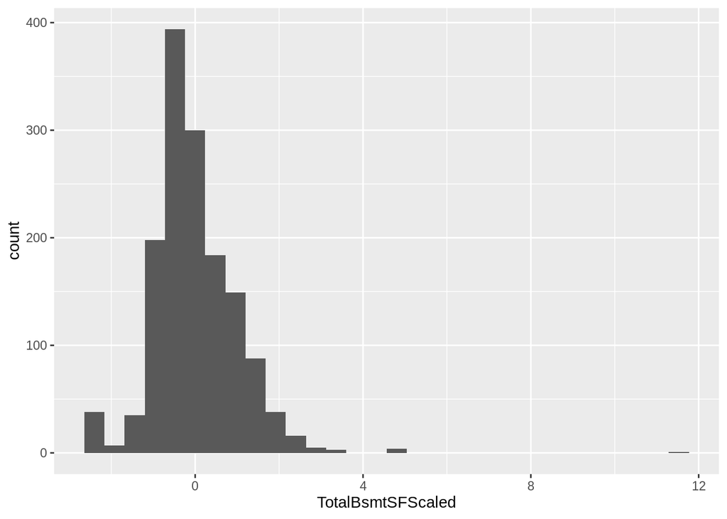

```r
df %>%
  mutate(TotalBsmtSFScaled=(TotalBsmtSF - mean(TotalBsmtSF)) / sd(TotalBsmtSF)) %>%
  ggplot(aes(x=TotalBsmtSFScaled)) +
  geom_histogram()
```

```r
library(MASS)
lambda <- df$TotalBsmtSF %>% fitdistr(densfun='exponential')
rate = lambda$estimate
```

Find the optimal value of $\lambda$ for this distribution, and then take 1000 samples from this exponential distribution using this value (e.g., rexp(1000, $\lambda$)). Plot a histogram and compare it with a histogram of your original variable.

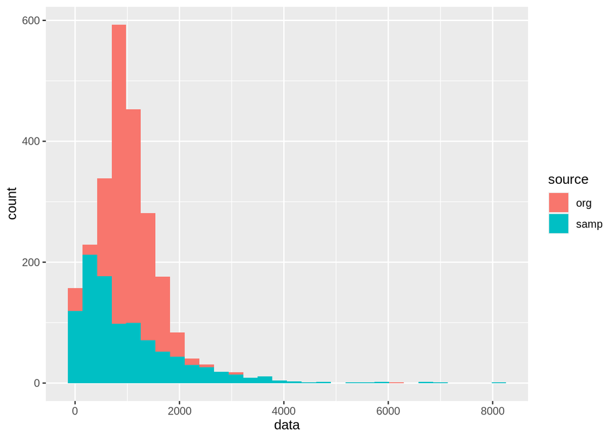

```r
exp_sample <- data.frame(source=c('samp'), data=rexp(1000, rate=rate))
exp_df <- rbind(exp_sample, data.frame(source=c('org'), data=df$TotalBsmtSF))
exp_df %>% ggplot(aes(x=data, fill=source)) +
  geom_histogram()
```

The original data has higher counts than the exp sample.

Using the exponential pdf, find the 5th and 95th percentiles using the cumulative distribution function (CDF).

```r
quantile(exp_sample$data, probs = c(0.05, 0.95))
```

```
##         5%        95%
##   54.91865 2959.85603
```

Also generate a 95% confidence interval from the empirical data, assuming normality. Finally, provide the empirical 5th percentile and 95th percentile of the data. Discuss.

```r
quantile(df$TotalBsmtSF, probs = c(0.05, 0.95))
```

```
##     5%    95%
##  519.3 1753.0
```

```r
pe <- mean(df$TotalBsmtSF)
stdev <- sd(df$TotalBsmtSF)
n = length(df$TotalBsmtSF)

se = stdev /sqrt(n)

print(c(pe - 1.96 * se, pe + 1.96 * se))
```

```
## [1] 1034.926 1079.933
```

#### Modeling.

Build some type of multiple regression model and submit your model to the competition board. Provide your complete model summary and results with analysis. Report your Kaggle.com user name and score.

```r
df <- df %>%
  dplyr::select(where(is.numeric)) %>%
  dplyr::select(-c('Id', 'YearRemodAdd', 'GarageYrBlt', 'MasVnrArea', 'MSSubClass', 'BsmtFinSF2', 'X3SsnPorch', 'YrSold', 'MoSold', 'MiscVal', 'BsmtHalfBath', 'LowQualFinSF'))

model_features = colnames(df)[1:25]
```

Split the data into training and testing sets. Using the training set bootstrap folds that will be used for tuning.

```r
df_split <- initial_split(df, strata=SalePrice)
df_train <- training(df_split)
df_test <- testing(df_split)
df_folds <- bootstraps(df_train, starta=SalePrice)
```

Create a recipe that will fill all missing values using knnimpute. Build the specifications for a random forest model, set the mtry and min_n as tuneable parameters Finally create the workflow for the recipe to the model spec

```r
model_rec <- recipe(SalePrice ~., data=df_train) %>%
  step_knnimpute(all_numeric())
model_spec <- rand_forest(mtry = tune(), min_n=tune(), trees = 1000) %>%
  set_mode('regression') %>%
  set_engine('ranger')

model_workflow <- workflow() %>%
  add_recipe(model_rec) %>%
  add_model(model_spec)
```

Using multiple cores train all the trees for the best root-mean squared error and $r^2$

```r
set.seed(42)
doParallel::registerDoParallel()
model_tune <- tune_grid(model_workflow, resample=df_folds, grid=10)
```

```
## i Creating pre-processing data to finalize unknown parameter: mtry
```

The error metric for this competition is rmse, so the best params corresponding to the lowest rmse will be chosen.

```r
show_best(model_tune, metric='rmse')
```

```
## # A tibble: 5 x 8
##    mtry min_n .metric .estimator   mean     n std_err .config
##   <int> <int> <chr>   <chr>       <dbl> <int>   <dbl> <chr>
## 1    11    10 rmse    standard   32700.    25    912. Preprocessor1_Model04
## 2     8    20 rmse    standard   32914.    25    886. Preprocessor1_Model10
## 3    15     8 rmse    standard   33009.    25    937. Preprocessor1_Model07
## 4     9    27 rmse    standard   33170.    25    876. Preprocessor1_Model05
## 5    14    34 rmse    standard   33730.    25    890. Preprocessor1_Model03
```

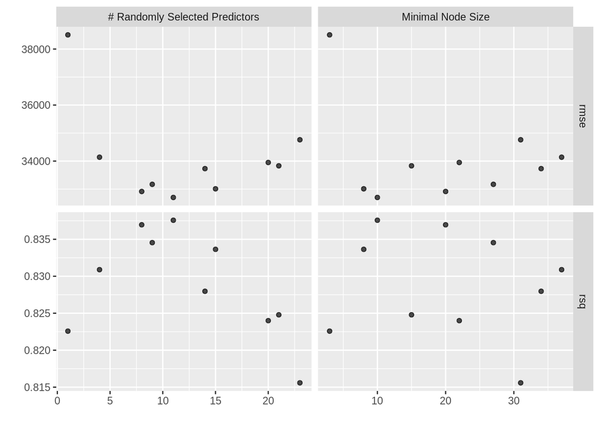

```r
autoplot(model_tune)
```

Using the best params fit the model and evaluate it on the the test set

```r
model_final <- model_workflow %>% finalize_workflow(select_best(model_tune, 'rmse'))
model_fit <- last_fit(model_final, df_split)
```

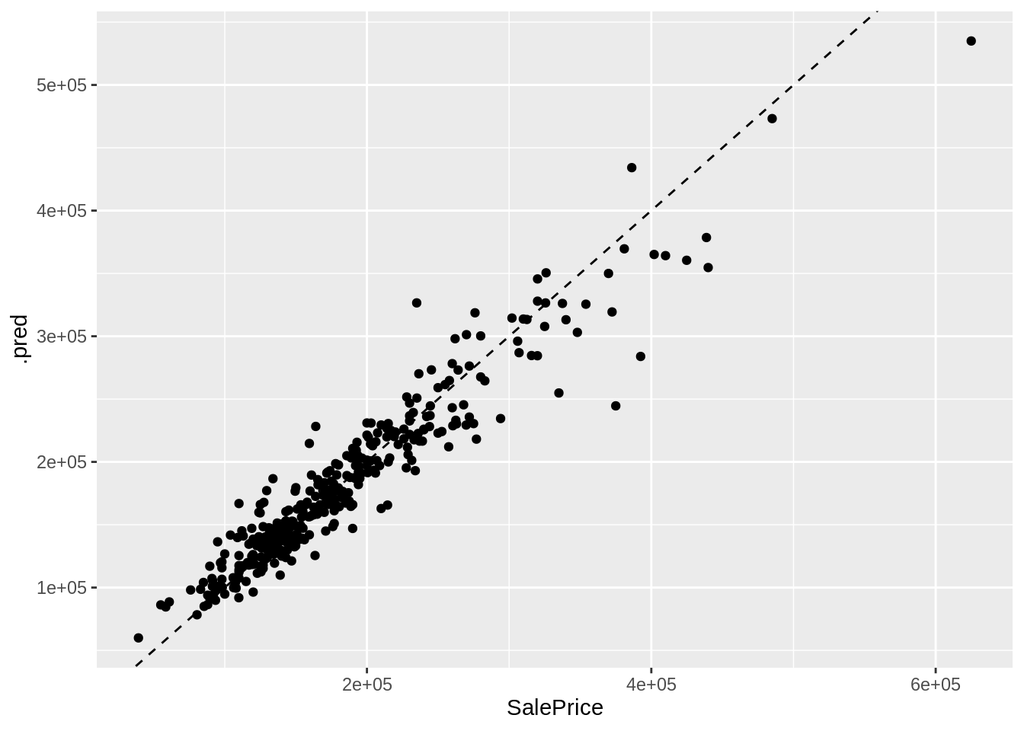

```r
collect_predictions(model_fit) %>%
  ggplot(aes(x=SalePrice, y=.pred)) +
  geom_abline(lty=2) +
  geom_point()
```

The importance plot shows that OverallQual, GrLivArea and YearBuilt contribute the most to the SalePrice

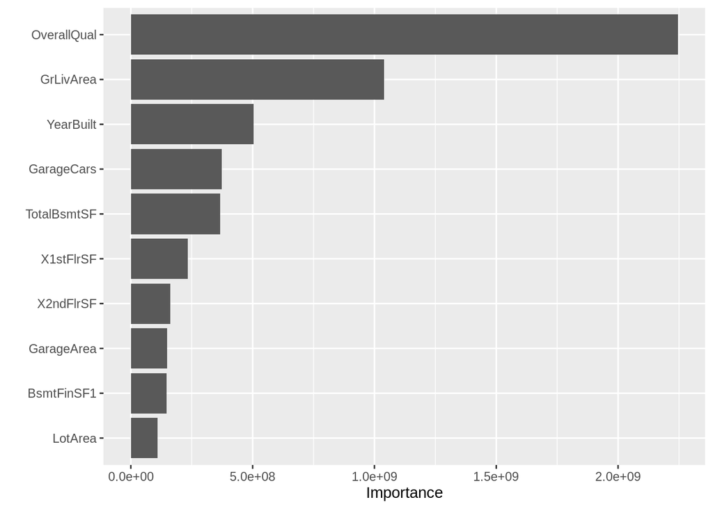

```r
sale_spec <- model_spec %>%
  finalize_model(select_best(model_tune, 'rmse')) %>%
  set_engine('ranger', importance='permutation')

workflow() %>%
  add_recipe(model_rec) %>%
  add_model(sale_spec) %>%
  fit(df_train) %>%
  pull_workflow_fit() %>%
  vip()
```

Finally with the final model making predictions and submit results to kaggle.

```r
model <- model_fit$.workflow[[1]]
testing_df <- tdf %>%
  dplyr::select(all_of(model_features)) %>%
  mutate(LotFrontage=ifelse(is.na(LotFrontage), median(LotFrontage, na.rm=T), LotFrontage)) %>%
  mutate(BsmtFinSF1=ifelse(is.na(BsmtFinSF1), median(BsmtFinSF1, na.rm=T), BsmtFinSF1)) %>%
  mutate(BsmtUnfSF=ifelse(is.na(BsmtUnfSF), median(BsmtUnfSF, na.rm=T), BsmtUnfSF)) %>%
  mutate(TotalBsmtSF=ifelse(is.na(TotalBsmtSF), median(TotalBsmtSF, na.rm=T), TotalBsmtSF)) %>%
  mutate(BsmtFullBath=ifelse(is.na(BsmtFullBath), median(BsmtFullBath, na.rm=T), BsmtFullBath)) %>%
  mutate(GarageCars=ifelse(is.na(GarageCars), median(GarageCars, na.rm=T), GarageCars)) %>%
  mutate(GarageArea=ifelse(is.na(GarageArea), median(GarageArea, na.rm=T), GarageArea)) %>%
  mutate_all(as.integer)

final_df <- sdf %>%
  mutate(SalePrice=predict(model, testing_df)$.pred)

write.csv(final_df, file=paste0(path, 'sample_submission_df_v1.csv'), row.names=F)
```

[figure not shown]